# Informe del Curso de Programación

Grupo 3

20/9/2020

# Porcentaje Sin Ingresos Propios

Primero, cargamos las librerias que necesitaremos para realizar el trabajo

```r
library(ggplot2)
library(tidyverse)
```

Cargamos el archivo csv que contiene los datos de hombres y mujeres sin ingresos propios tanto nacional, rural y urbano

```r
data <- read.csv("C:/Users/NEYSSER/Desktop/ciclo _5 _IG/porcentaje_sin_ingresos_propios.csv")
head(data)
```

```
##    Año Nac_Mujeres Nac_Hombres Urb_Mujeres Urb_Hombres Rur_Mujeres Rur_Hombres
## 1 2007        34.4        12.3        28.9        11.7        51.4        14.1
## 2 2008        33.4        12.3        28.2        11.5        49.8        14.6
## 3 2009        33.3        12.4        28.1        11.7        50.4        14.5
## 4 2010        31.6        11.9        26.4        11.3        49.3        13.7
## 5 2011        32.4        12.4        27.5        11.7        49.7        14.6
## 6 2012        32.1        12.1        27.5        11.5        48.6        14.1
```

Usamos gather para fundir o agrupar los datos de las zonas rurales y urbanas en comparacion con los años y su porcentaje luego dejamos intacto los datos a nivel nacional, y con head podemos visualizar los datos parcialmente

```r
df <- data %>%
  gather(key = "Zona", value = "Porcentaje", -Año, -Nac_Mujeres, -Nac_Hombres)
head(df)
```

```
##    Año Nac_Mujeres Nac_Hombres        Zona Porcentaje
## 1 2007        34.4        12.3 Urb_Mujeres       28.9
## 2 2008        33.4        12.3 Urb_Mujeres       28.2
## 3 2009        33.3        12.4 Urb_Mujeres       28.1
## 4 2010        31.6        11.9 Urb_Mujeres       26.4
## 5 2011        32.4        12.4 Urb_Mujeres       27.5
## 6 2012        32.1        12.1 Urb_Mujeres       27.5
```

## Construimos el Grafico con ggplot

Agrupamos los datos de las zonas rurales y urbanas para colocarlo en el aes y agruparlo, darle color según ello

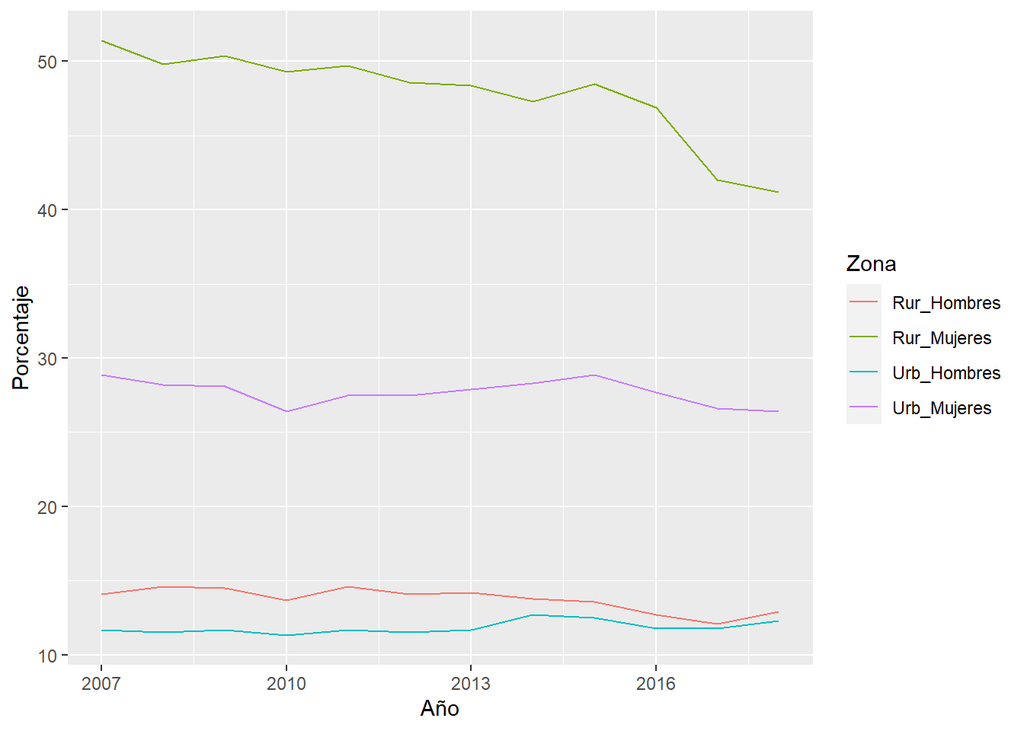

```r
ggplot(df, aes(Año, Porcentaje, group = Zona)) +
  geom_line(aes(color = Zona))
```

Como vemos en el grafico nos hes un poco dificil relacionar o encontrar cual linea representa cada valor. Asi que modificaremos el grafico con las distintas posibilidades que nos ofrece ggplot

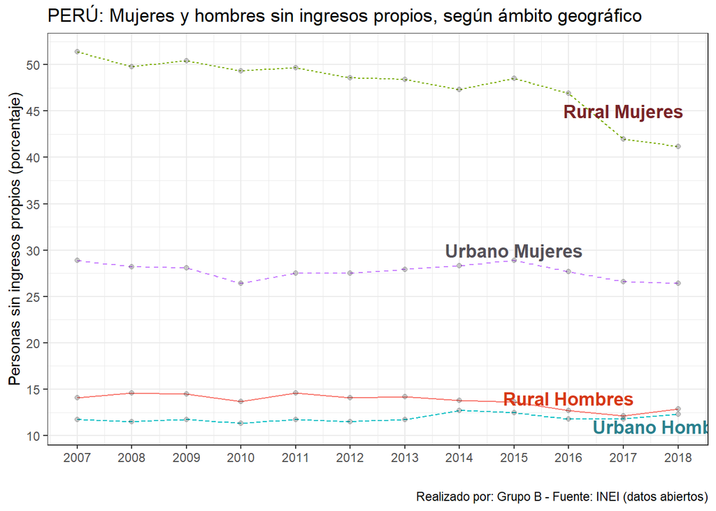

```r
n <- ggplot(df, aes(Año, Porcentaje, group = Zona)) +

# Configuramos la forma de la linea segun la zona
  geom_line(aes(linetype = Zona, color= Zona)) +

# Añadimos los puntos en cada año y le damos transparencia
  geom_point(alpha = .2) +

# Escribimos el titulo y la descricion de la imagen al pie de pagina
  ggtitle("PERÚ: Mujeres y hombres sin ingresos propios, según ámbito geográfico") +
  labs(caption="Realizado por: Grupo B - Fuente: INEI (datos abiertos)") +

# Los nombres de los ejes (en el caso del eje "x" lo dejamos en blanco porque se sobreentiende)
  xlab("") +
  ylab("Personas sin ingresos propios (porcentaje)") +

# Configurar el "x" para que se separe cada año
  scale_x_continuous(breaks = seq(2007, 2018, 1)) +

# De manera similar el eje "y", intervalo considerado sera cada 5
  scale_y_continuous(
    breaks = seq(10, 60, 5)
  ) +

# Las siguiente lineas son anotaciones hechas a mano para cada linea
  annotate("text",
           x = 2017,
           y = 45,
           label = "Rural Mujeres",
           color = "#792427",
           fontface = "bold",
           size = 4.5) +

  annotate("text",
           x = 2015,
           y = 30,
           label = "Urbano Mujeres",
           color = "#545058",
           fontface = "bold",
           size = 4.5) +

  annotate("text",
           x = 2016,
           y = 14,
           label = "Rural Hombres",
           color = "#D73815",
           fontface = "bold",
           size = 4.5) +

  annotate("text",
           x = 2017.8,
           y = 11,
           label = "Urbano Hombres",
           color = "#2B818E",
           fontface = "bold",
           size = 4.5) +

  # Selecionamos un tema de fondo
  theme_bw() +

  # Eliminamos la leyenda
  theme(legend.position = "none")

n
```

## Conclusión

Podria ser que las mujeres de area rural son mayor porcentaje en cuanto a no contar con ingresos propios aunque en los ultimos años tiene tendendia a bajar. Los hombres de las zonas rurales y urbanas tienen un aproximado porcentaje en los ultimos años

# Relación Temperatura-Salinidad en el mar peruano